# 2022-10-20组会汇报

## **简介**

> 大家好，今天给大家汇报一下我最近的研究进展，内容包括以下6个部分：`1.被试作答异常相关的基础知识；` `2.机器学习中深度学习方法的简单介绍；` `3.认知诊断下作答异常检测相关研究；` `4.本研究所用到的联合反应时模型介绍；` `5.本研究的实验设计、参数设定的介绍；` `6.已得结果的展示。`

## **一、被试作答异常相关的基础知识**

模型资料拟合一般分为三种：  
1.测验拟合  
2.项目拟合  
3.被试拟合  
我们说的被试作答异常，就属于第三种。而作答异常又可以分很多种，如：分数增益、答案预知、串通作弊、考后答案更改、睡眠作答、疲劳作答、随机猜测、粗心大意、低动机作答、后半段加速作答等。我们把这些行为统一叫做“异常行为”（aberrant behavior）。  
异常行为检测发展至今，已经有很多检验的方法，下面介绍一些比较主流的异常行为检测的统计量或方法：  
- IRT模型下：$l_{z}$、$l_{z}^{*}$、$NCI$、$H^{T}$、$ω$、$erasure$ $detection$ $index$、$CPA$ 等。  
- CD模型下：$HCI$、$LRT$、$l_{z}$、$RCI$、$RI$ 等 。  
- RT模型下：卡方(residual) 统计、$l_{t}$ 等。  
- 最近流行的机器学习，数据发掘的方法！

## **二、机器学习中深度学习方法的简单介绍**

随着目前计算机算力和算法的不断提升，加上线上测验的考试增多，上面提到的，机器学习，数据发掘的方法，目前渐渐流行起来，它是以数据为驱动，发掘数据中的规律，从而建立模型。  
机器学习分为有监督机器学习，无监督机器学习，半监督机器学习，每种类别下都有其所流行的机器学习算法。本研究所用到的神经网络方法，属于监督学习的一种。

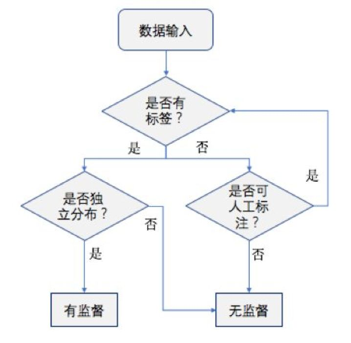

深度学习：

[figure not shown]

深度学习的概念源于人工神经网络的研究，但是并不完全等于传统神经网络。不过在叫法上，很多深度学习算法中都会包含”神经网络”这个词，比如：卷积神经网络、循环神经网络。所以，深度学习可以说是在传统神经网络基础上的升级，约等于神经网络。

[figure not shown]

深度学习大致就是这么一个用人类的数学知识与计算机算法构建起来的整体架构，再结合尽可能多的训练数据以及计算机的大规模运算能力去调节内部参数，尽可能逼近问题目标的半理论、半经验的建模方式。

[figure not shown]

深度学习的优缺点：

[figure not shown]

## **三、认知诊断下作答异常检测相关研究**

$$HCI_{i} = 1 - \frac{2\sum _{j\in
S_{correct_{i}} }\sum _{g\in S_{j}}X_{i_{j}}\left ( 1 - X_{i_{g}} \right
)}{N_{c_{i}}}$$

> $HCI$：层级一致性指标  
> $i$： 被试  
> $j/g$：题目  
> $X_{i_{j}}$：被试i在j题上的得分（0/1）  
> $X_{i_{g}}$：被试i在g题上的得分（0/1）  
> $S_{correct_{i}}$：被试i所答对的题目集合  
> $S_{j}$： 第j题的属性层级子集的题目集合  
> $N_{c_{i}}$：答对题目的数量

Cui 和 Li（2015）的研究表明，𝑅𝐶𝐼指标优于 Liu 等（2009）的似然比统计量，故没有介绍。
$$RCI_{i} = \sum_{J}^{j = 1}\left | RCI_{ij}
\right | = \sum_{J}^{j = 1} \left | ln\left [ -\frac{X_{ij}-P_{j\left (
\alpha _{i} \right )}}{I_{j\left (\alpha _{i} \right )}-P_{j\left (
\alpha _{i} \right )}} \right ]^{X_{ij}+I_{j\left ( \alpha _{i} \right
)}} \right |$$

> $RCI$：反应一致性指标  
> $i$： 被试  
> $j$： 题目  
> $α_i$：被试i的属性掌握模式  
> $X_{ij}$：被试i在j题上的得分（0/1）  
> $I_j(α_i)$：属性掌握模式$α_i$的被试对项目j的理想作答反应（0/1）  
> $P_j(α_i)$：属性掌握模式$α_i$的被试正确作答项目j的概率[0,1]

$$R_i=\sum_{j=1}^{J}log\left [
\frac{x_{ij} - E\left ( x_{ij}|\alpha _{i} \right )}{P\left (
x_{ij}|\alpha _{i} \right )} \right ]^{2}$$

> $RI$：残差指标  
> $i$： 被试  
> $j$： 题目  
> $α_i$：被试i的属性掌握模式  
> $x_{ij}$：被试i在j题上的得分（0/1）  
> $E\left ( x_{ij}|\alpha _{i} \right )$：属性掌握模式为α_i的被试i在项目j上的期望得分[0,1]  
> $P\left ( x_{ij}|\alpha _{i} \right )$：属性掌握模式α_i的被试i在项目j上得x_ij分的概率[0,1]

$$l_{0} = ln\left \{ \prod_{j=1}^{J}
P_{j\left ( \theta _{i} \right )}^{X_{ij}} \left [ 1- P_{j\left ( \theta
_{i} \right )}^{X_{ij}} \right ]^{1-X_{ij}}\right \}$$

> $i$：被试  
> $j$：题目  
> $θ_i$：被试i的能力  
> $X_{ij}$：被试i在j题上的得分（0/1）

$$l_{z} = \frac{l_{0} - E\left (
l_{0} \right )}{\sqrt{var\left ( l_{0} \right )}}$$

## **四、本研究所用到的联合反应时模型介绍**

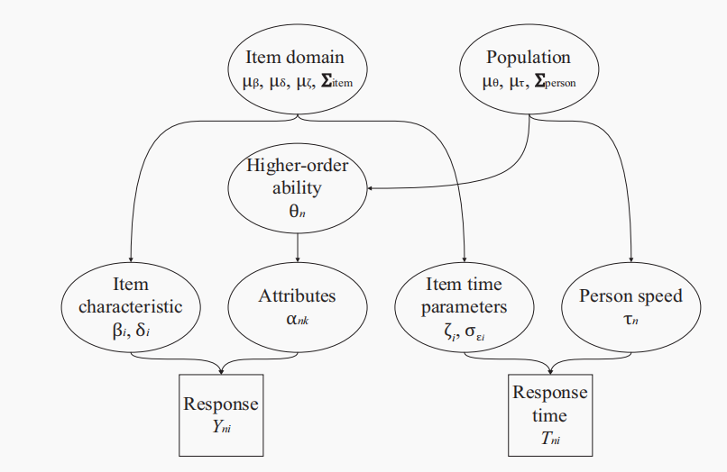

A graphical representation of the JRT-DINA model

Log-normal RT model:

$$log\left ( T_{ni} \right ) = \zeta _{i}
- \tau _{n} + \varepsilon _{ni}, \varepsilon _{ni}\sim N\left ( 0,\sigma
_{\varepsilon i}^{2} \right )$$

DINA model:

$$P\left ( Y_{ni} = 1 \right ) =
g_{i}+\left ( 1-s_{i}-g_{i} \right )\prod_{k=1}^{K}\alpha _{nk}^{q_{ik}}$$

> $g_{i}$：猜测参数  
> $s_{i}$：失误参数  
> $q_{ik}$：Q向量  
> $\alpha_{nk}$：被试n在k个属性上的属性掌握模式

However, since $\alpha_{nk}$ is a binary variable and $s_{i}$ and $g_{i}$ are on the probability scale, the multivariate normal distribution cannot be directly used. Thus, two reparameterizations are applied:
$$\beta _{i}=logit\left ( g_{i} \right )$$
$$\delta _{i}=logit\left ( 1-s_{i}
\right )-logit\left ( g_{i} \right )$$
Where $logit\left ( x \right )= log\left ( \frac{x}{1-x} \right )$ Thus, $P\left ( Y_{ni} = 1 \right )$ can be reformulated as:

$$logit\left ( P\left ( Y_{ni} = 1 \right
) \right ) = \beta _{i}+\delta _{i}\prod_{k=1}^{K}\alpha _{nk}^{q_{ik}}$$

Further, since attributes in a test are often conceptually related and statistically correlated in practice (de la Torre & Douglas, 2004; Templin, 2004), it would be more helpful to formulate a higher-order structure to link the correlated attributes (de la Torre & Douglas, 2004) as:

$$logit\left ( P\left ( \alpha_{nk} = 1
\right ) \right )=\gamma _{k}\theta _{n}-\lambda _{k}$$

## **五、本研究的实验设计、参数设定的介绍**

前面说到，我们的研究方法属于有监督学习，需要带标签的数据用来训练神经网络，但由于研究的特殊性，无法获取大批量异常作答行为的数据，因此，本研究所有的正常和异常数据都通过数据模拟的方式来生成。同时，我们要注意的是，检测异常行为可以看作是一个分类问题。一般的做法是将类别分为”正常”、“异常”两类，而本研究则细分了类别，观察是否能在检测异常作答的同时，检测出异常行为的类型。

> 本研究设置了3种异常类型： 后段加速作答（高能力者答错困难的题目）、作弊（低能力者答对困难的题目）、全卷随机猜测（低答题动机者胡乱作答）。

其中，属于后段加速作答的考试属性掌握模式最多少掌握一个属性，如3属性的测试，有4种类别；属于作弊考生的考试属性掌握模式，除了全掌握外，其他的属性掌握模式都有可能，如3属性的测试，有2^3 - 1 = 7种类别；属于全卷随机猜测的考生每种属性掌握模式都有可能发生，所有就只归为一个类别。最终加上正常作答的类别，如3属性的测试，有2^3 = 8种类别，就有4 + 7 + 1 + 8 = 20个细分种类。同理，6属性就有7 + 63 + 1 + 64 = 135个细分种类。

> 每个种类各生成500个被试作训练集，500个被试作验证集，500个被试作测试集。

#### 实验设计：

- 因素1：测验属性数（3属性 – 6属性）– Q矩阵固定  
- 因素2：测验题目数（3属性：10/20/40题 – 6属性：20/40题）  
- 因素3：题目质量（高 – 低）  
- 因素4：异常题目比例（0.1 – 0.2）  
- 因素5：是否加入反应时数据（是 – 否）

#### 参数设定：

```r
## 被试参数设置
theta_tau_mean <- c(0, 0)
theta_tau_covariance <- matrix(c(1, -0.23, -0.23, 0.205), nrow=2, ncol=2)
print(theta_tau_covariance)
```

```
##       [,1]   [,2]
## [1,]  1.00 -0.230
## [2,] -0.23  0.205
```

```r
gamma_vector <- 1
lambda_vector <- 0
```

```r
## 项目参数设置
item_quality <-  "low"
if (item_quality == "low") {
  gs_mean <- 0.25
} else if (item_quality == "high") {
  gs_mean <- 0.1
}
mean_beta <- log(gs_mean / (1 - gs_mean))
mean_delta <- log((1 - gs_mean) / gs_mean) - mean_beta
mean_zeta <- 3
print(exp(mean_zeta))
```

```
## [1] 20.08554
```

```r
beta_delta_zata_mean <- c(mean_beta, mean_delta, mean_zeta)
beta_delta_zata_covariance <- matrix(c(3.863, -2.454, -0.444,
                                      -2.454,  2.501,  0.25,
                                      -0.444,  0.25,   0.242), nrow=3, ncol=3)
print(beta_delta_zata_mean)
```

```
## [1] -1.098612  2.197225  3.000000
```

```r
print(beta_delta_zata_covariance)
```

```
##        [,1]   [,2]   [,3]
## [1,]  3.863 -2.454 -0.444
## [2,] -2.454  2.501  0.250
## [3,] -0.444  0.250  0.242
```

```r
item_num <- 10
sigma_epsilon <- runif(item_num, 0.4, 0.6)
```

```r
## 数据筛选截断值
zeta_low <- 3
zeta_high <- 4.5
total_RT_high <- exp(zeta_high) * item_num
total_RT_low <- exp(zeta_low) * item_num

theta_tau_low <- -3
theta_tau_high <- 3

if (item_quality == "low") {
  s_g_low <- 0.4
} else if (item_quality == "high") {
  s_g_high <- 0.2
}
```

```r
## 异常反应时生成公式：final_log_RT = original_log_RT - d * 0.5
d <- 3
```

```python
## keras 参数设置

# layer_one = x_train.shape[1] - 1
# batch_size = int(x_train.shape[0] / 1000)
# learning_rate = 0.0001
# epochs = 100
#
# model = Sequential()
# model.add(Dense(units = layer_one, input_dim = x_train.shape[1], activation = "relu"))
# model.add(Dense(units = y_train.shape[1], activation = "softmax"))
#
# adam = Adam(learning_rate = learning_rate)
#
# model.compile(optimizer = adam, loss = "categorical_crossentropy", metrics = ['accuracy'])
```

## **六、已得结果的展示**

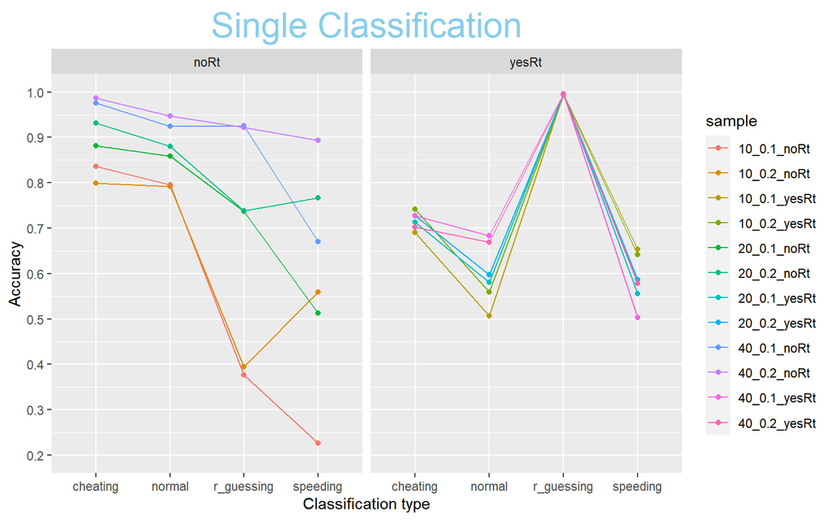

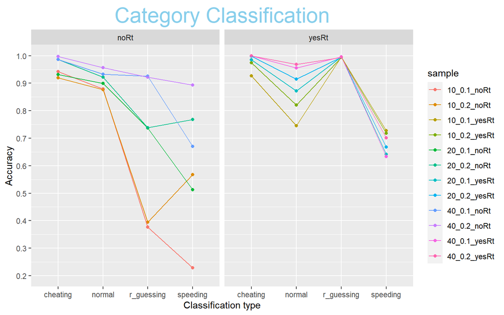

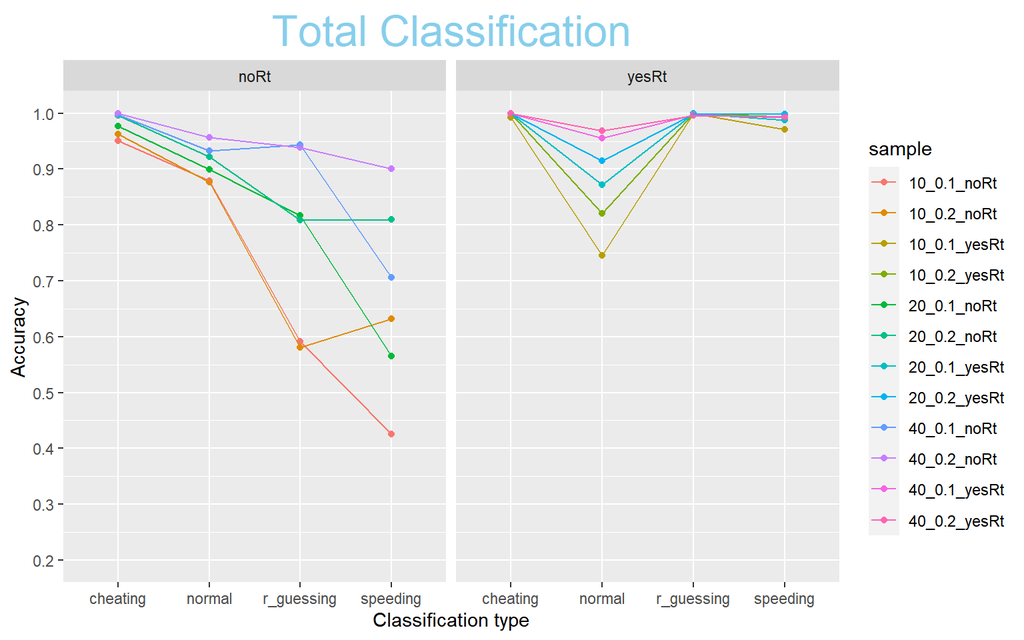